# Urban Columbidae Communities

```r
library(dplyr)
library(purrr)
library(tidyverse)
library(tidyr)


library(phytools)
library(picante)
library(abdiv)
library(vegan)
library(fundiversity)
library(ggpubr)
library(gridExtra)
library(grid)
```

# Introduction

## Are urban columbidae communities strutured by habitat filtering or via competitive interactions?

- With competitive interactions we expect the phylogenetic and functional distance between species to higher than expected than within a random community.
- With habitat filtering we expect the phylogentic and functional distance between species to be lower than expected than within a random community. (Swenson et al. 2007; Cavender-Bares et al. 2009).

## Recommended community metrics (Trisos et al. 2014)

- Functional diversity of all traits (Petchey and Gaston 2002)
- Convex Hull Volume (CHV) of all traits (a multivariate measure of the range of community values) (Cornwell et al. 2006)
- Mean taxon distance (MTD) is mean pairwise phylogenetic distances between co-occurring species and is most sensitive to tree-wide patterns of phylogenetic clustering and evenness.
- Mean nearest taxon distance (MNTD) is mean pairwise phylogenetic distances separating each species from its closest co-occurring relative and is most sensitive to phylogenetic clustering or evenness at the tips of phylogeny.
- FD of each trait individually
- Variance of each trait within community previously used to measure trait clustering
- SDNDr (standard deviation of distances between neighbouring species along a single trait axis, divided by the trait range of the community) is used to detect the regular spacing in species trait values predicted by competitive exclusion.

## Recommended traits (Trisos et al. 2014)

- Overall body size.
- Trophic - beak shape (beak length, width, depth) - measures competitive exclusion (e.g. over-dispersion) via accentuation of foraging differences
- Locomotory (wing, tail, tarsus length)

## Recommended null model (Milar et al. 2017)

Many metrics sensitive to species richness. Urban communities are governed by the surrounding regional pool. For each urban community, we can generate all of the possible communities with the same species richness as the urban community with species from the regional pool. The average of all possible communities gives us a null model.

# Community data

We used all cities with a population of 250,000 or more, and that have at least 167 complete checklists that are more than 5 and less than 240 minutes in length and cover no more than 10km. We then included any Columbidae species in the urban community that appeared on at least 5% of all of these checklists recorded within the city.

This criteria comes from choosing all cities with at least 1000 checklists, and then testing 1000 times how many checklists are required to find all those species that appear on at least 5% of the total checklists. 269 cities were included in this test, and 167 was the maximum number of checklists required to find all min-5% species (which was in Auckland).

## Read in data exported from bigquery

```r
all_columbidae_communities = read_csv('../../data/bigquery/columbidae_jetz__urban_locations.csv')
head(all_columbidae_communities)
```

| city_id | city_name | jetz_scientific_name | present_in_city | season_code | season | origin_code | origin |
| --- | --- | --- | --- | --- | --- | --- | --- |
| 1 | Honolulu | Stigmatopelia_chinensis | FALSE | 1 | Resident | 3 | Introduced |
| 514 | Cali | Columbina_passerina | FALSE | 1 | Resident | 1 | Native |
| 514 | Cali | Columbina_talpacoti | TRUE | 1 | Resident | 1 | Native |
| 514 | Cali | Geotrygon_montana | FALSE | 1 | Resident | 1 | Native |
| 514 | Cali | Claravis_mondetoura | FALSE | 1 | Resident | 1 | Native |
| 514 | Cali | Leptotila_plumbeiceps | FALSE | 1 | Resident | 1 | Native |

# Site Selection

Our site metrics all compare species within communities, therefore we must have more than one species in each urban community for our analysis. Our null model requires us to create a range of dissimilar communities with the same richness as the actual urban community using species from the regional pool, therefore we must have less than the number of species in our regional pool in our urban pool.

Here we exclude then two sets of urban communities that are interesting in their own right, (1) those with 1 or less species, and (2) those with all the species from the regional pool

```r
urban_communities_tmp = all_columbidae_communities %>% group_by(city_id, city_name) %>% summarise(regional_pool_size = n(), urban_pool_size = sum(present_in_city), number_of_regional_introduced_species = sum(origin == 'Introduced'), number_of_urban_introduced_species = sum(origin == 'Introduced' & present_in_city))
head(urban_communities_tmp)
```

| city_id | city_name | regional_pool_size | urban_pool_size | number_of_regional_introduced_species | number_of_urban_introduced_species |
| --- | --- | --- | --- | --- | --- |
| 1 | Honolulu | 1 | 0 | 1 | 0 |
| 8 | Oxnard | 3 | 2 | 0 | 0 |
| 10 | San Jose | 3 | 1 | 0 | 0 |
| 19 | Concord | 2 | 1 | 0 | 0 |
| 20 | Ensenada | 3 | 0 | 0 | 0 |
| 21 | Tijuana | 4 | 1 | 0 | 0 |

Communities with 1 or less pigeon species

```r
urban_communities_tmp[urban_communities_tmp$urban_pool_size < 2,]
```

| city_id | city_name | regional_pool_size | urban_pool_size | number_of_regional_introduced_species | number_of_urban_introduced_species |
| --- | --- | --- | --- | --- | --- |
| 1 | Honolulu | 1 | 0 | 1 | 0 |
| 10 | San Jose | 3 | 1 | 0 | 0 |
| 19 | Concord | 2 | 1 | 0 | 0 |
| 20 | Ensenada | 3 | 0 | 0 | 0 |
| 21 | Tijuana | 4 | 1 | 0 | 0 |
| 26 | Antioch | 2 | 1 | 0 | 0 |
| 29 | Bakersfield | 3 | 1 | 0 | 0 |
| 32 | Palmdale | 3 | 1 | 0 | 0 |
| 34 | Stockton | 2 | 1 | 0 | 0 |
| 35 | Modesto | 2 | 1 | 0 | 0 |

[output cut: 186 more lines]

Communities with all regional species

```r
urban_communities_tmp[urban_communities_tmp$urban_pool_size == urban_communities_tmp$regional_pool_size,]
```

| city_id | city_name | regional_pool_size | urban_pool_size | number_of_regional_introduced_species | number_of_urban_introduced_species |
| --- | --- | --- | --- | --- | --- |
| 73 | Culiacán | 6 | 6 | 0 | 0 |
| 111 | Chihuahua | 3 | 3 | 0 | 0 |
| 172 | Boise | 1 | 1 | 0 | 0 |
| 192 | Provo | 1 | 1 | 0 | 0 |
| 193 | Salt Lake City | 1 | 1 | 0 | 0 |
| 207 | Ogden | 1 | 1 | 0 | 0 |
| 241 | Spokane | 1 | 1 | 0 | 0 |
| 266 | Colorado Springs | 1 | 1 | 0 | 0 |
| 273 | Denver | 1 | 1 | 0 | 0 |
| 351 | Oklahoma City | 1 | 1 | 0 | 0 |

[output cut: 53 more lines]

Selected sites:

```
models:
  - name: selected_urban_communities
    description: Sites that we will analyse that have more than 1 species, and less species than the entire regional pool
    columns:
      - name: city_id
        description: Vector ID from GHSL Data Package 2019 (Pesaresi et al. 2019)
      - name: city_name
        description: City name from Vector from GHSL Data Package 2019 (Pesaresi et al. 2019)
      - name: regional_pool_size
        description: the number of columbidae species in the city regional pool, e.g. number of species where the city vector overlaps the birdlife distribution vector
      - name: urban_pool_size
        description: the number of columbidae species that occur inside the city, e.g. the number of columbidae species that appear on at least 5% of all valid checklists within the city vector.
      - name: number_of_regional_introduced_species
        description: the number of columbidae species in the regional pool that are introduced, e.g. have origin 'Introduced' from the Birdlife distribution vector.
      - name: number_of_urban_introduced_species
        description: the number of columbidae species present inside the city that are introduced, e.g. have origin 'Introduced' from the Birdlife distribution vector.
```

```r
selected_urban_communities = urban_communities_tmp[urban_communities_tmp$urban_pool_size > 1 & urban_communities_tmp$urban_pool_size != urban_communities_tmp$regional_pool_size,]
nrow(selected_urban_communities)
```

```
[1] 307
```

```r
head(selected_urban_communities)
```

| city_id | city_name | regional_pool_size | urban_pool_size | number_of_regional_introduced_species | number_of_urban_introduced_species |
| --- | --- | --- | --- | --- | --- |
| 8 | Oxnard | 3 | 2 | 0 | 0 |
| 56 | Indio | 4 | 2 | 0 | 0 |
| 65 | Hermosillo | 5 | 3 | 0 | 0 |
| 74 | Las Vegas | 5 | 2 | 0 | 0 |
| 75 | Mazatlán | 8 | 4 | 0 | 0 |
| 79 | Phoenix | 5 | 3 | 0 | 0 |

And therefore

```r
selected_columbidae_communities = all_columbidae_communities[all_columbidae_communities$city_id %in% selected_urban_communities$city_id,]
head(selected_columbidae_communities)
```

| city_id | city_name | jetz_scientific_name | present_in_city | season_code | season | origin_code | origin |
| --- | --- | --- | --- | --- | --- | --- | --- |
| 514 | Cali | Columbina_passerina | FALSE | 1 | Resident | 1 | Native |
| 514 | Cali | Columbina_talpacoti | TRUE | 1 | Resident | 1 | Native |
| 514 | Cali | Geotrygon_montana | FALSE | 1 | Resident | 1 | Native |
| 514 | Cali | Claravis_mondetoura | FALSE | 1 | Resident | 1 | Native |
| 514 | Cali | Leptotila_plumbeiceps | FALSE | 1 | Resident | 1 | Native |
| 514 | Cali | Leptotila_verreauxi | FALSE | 1 | Resident | 1 | Native |

Total number of species across regional pools:

```r
length(unique(selected_columbidae_communities$jetz_scientific_name))
```

```
[1] 149
```

Total number of species across cities:

```r
length(unique(selected_columbidae_communities$jetz_scientific_name[selected_columbidae_communities$present_in_city]))
```

```
[1] 65
```

## Create a second set containing only Resident species

We have shown that non-resident species are less likely to be present in urban communities; however, this could be temporal sampling bias that means non-resident species are less likely to appear on at least 5% of all checklists. Therefore we should validate our findings against a second dataset that contains only resident species.

```r
all_resident_columbidae_communities = all_columbidae_communities[all_columbidae_communities$season == 'Resident',]
head(all_resident_columbidae_communities)
```

| city_id | city_name | jetz_scientific_name | present_in_city | season_code | season | origin_code | origin |
| --- | --- | --- | --- | --- | --- | --- | --- |
| 1 | Honolulu | Stigmatopelia_chinensis | FALSE | 1 | Resident | 3 | Introduced |
| 514 | Cali | Columbina_passerina | FALSE | 1 | Resident | 1 | Native |
| 514 | Cali | Columbina_talpacoti | TRUE | 1 | Resident | 1 | Native |
| 514 | Cali | Geotrygon_montana | FALSE | 1 | Resident | 1 | Native |
| 514 | Cali | Claravis_mondetoura | FALSE | 1 | Resident | 1 | Native |
| 514 | Cali | Leptotila_plumbeiceps | FALSE | 1 | Resident | 1 | Native |

```r
resident_urban_communities_tmp = all_resident_columbidae_communities %>% group_by(city_id, city_name) %>% summarise(regional_pool_size = n(), urban_pool_size = sum(present_in_city))
head(resident_urban_communities_tmp)
```

| city_id | city_name | regional_pool_size | urban_pool_size |
| --- | --- | --- | --- |
| 1 | Honolulu | 1 | 0 |
| 8 | Oxnard | 3 | 2 |
| 10 | San Jose | 2 | 1 |
| 19 | Concord | 2 | 1 |
| 20 | Ensenada | 3 | 0 |
| 21 | Tijuana | 3 | 1 |

Selected sites:

```
models:
  - name: selected_resident_only_urban_communities
    description: Sites that we will analyse that have more than 1 species, and less species than the entire regional pool based on species being within their Residential range (and not just Breeding, Migration, or non-Breeding range).
    columns:
      - name: city_id
        description: Vector ID from GHSL Data Package 2019 (Pesaresi et al. 2019)
      - name: city_name
        description: City name from Vector from GHSL Data Package 2019 (Pesaresi et al. 2019)
      - name: regional_pool_size
        description: the number of columbidae species in the city regional pool, e.g. number of species where the city vector overlaps the birdlife distribution vector
      - name: urban_pool_size
        description: the number of columbidae species that occur inside the city, e.g. the number of columbidae species that appear on at least 5% of all valid checklists within the city vector.
```

```r
selected_resident_only_urban_communities = resident_urban_communities_tmp[resident_urban_communities_tmp$urban_pool_size > 1 & resident_urban_communities_tmp$urban_pool_size != resident_urban_communities_tmp$regional_pool_size,]
nrow(selected_resident_only_urban_communities)
```

```
[1] 245
```

```r
head(selected_resident_only_urban_communities)
```

| city_id | city_name | regional_pool_size | urban_pool_size |
| --- | --- | --- | --- |
| 8 | Oxnard | 3 | 2 |
| 65 | Hermosillo | 5 | 3 |
| 75 | Mazatlán | 7 | 4 |
| 79 | Phoenix | 4 | 2 |
| 81 | Tepic | 8 | 4 |
| 83 | Colima | 8 | 3 |

And therefore

```r
selected_resident_columbidae_communities = all_resident_columbidae_communities[all_resident_columbidae_communities$city_id %in% selected_resident_only_urban_communities$city_id,]
head(selected_resident_only_urban_communities)
```

| city_id | city_name | regional_pool_size | urban_pool_size |
| --- | --- | --- | --- |
| 8 | Oxnard | 3 | 2 |
| 65 | Hermosillo | 5 | 3 |
| 75 | Mazatlán | 7 | 4 |
| 79 | Phoenix | 4 | 2 |
| 81 | Tepic | 8 | 4 |
| 83 | Colima | 8 | 3 |

# Trait Data

```r
source("../../data/third_party/columbidae_jetz__avonet.R")
avonet_jetz = avonet_in_jetz_taxonomy()
head(avonet_jetz)
```

| jetz_scientific_name | beak_length | beak_width | beak_depth | tail_length | wing_length | tarsus_length | trophic_niche | habitat | habitat_density | primary_lifestyle | range_size | mass |
| --- | --- | --- | --- | --- | --- | --- | --- | --- | --- | --- | --- | --- |
| Alectroenas_madagascariensis | 17.5 | 4.10 | 4.2 | 81.50 | 171.00 | 22.30 | Frugivore | Forest | 2 | Insessorial | 311714.7 | 173.0 |
| Aplopelia_larvata | 21.7 | 3.30 | 3.7 | 92.90 | 143.10 | 26.00 | Granivore | Forest | 2 | Terrestrial | 2621499.0 | 155.0 |
| Caloenas_nicobarica | 30.7 | 5.40 | 7.7 | 98.80 | 259.00 | 43.70 | Omnivore | Forest | 1 | Terrestrial | 475640.9 | 537.9 |
| Chalcophaps_indica | 21.8 | 2.95 | 4.1 | 85.45 | 147.95 | 25.85 | Omnivore | Forest | 1 | Generalist | 5343787.3 | 136.5 |
| Chalcophaps_stephani | 20.7 | 2.60 | 3.8 | 84.40 | 136.00 | 24.80 | Omnivore | Forest | 3 | Generalist | 866814.3 | 129.0 |
| Claravis_godefrida | 17.4 | 3.40 | 3.7 | 81.80 | 118.00 | 22.10 | Granivore | Forest | 1 | Terrestrial | 148131.9 | 43.5 |

## Creating trait values

### Trophic trait

```r
trophic_trait_pca = rda(avonet_jetz[,c('beak_length', 'beak_width', 'beak_depth')])
summary(trophic_trait_pca)
```

```
Call:
rda(X = avonet_jetz[, c("beak_length", "beak_width", "beak_depth")])

Partitioning of variance:
              Inertia Proportion
Total           27.59          1
Unconstrained   27.59          1

Eigenvalues, and their contribution to the variance

Importance of components:
                          PC1     PC2      PC3
Eigenvalue            25.9917 1.39132 0.203845
Proportion Explained   0.9422 0.05043 0.007389
Cumulative Proportion  0.9422 0.99261 1.000000

Scaling 2 for species and site scores
* Species are scaled proportional to eigenvalues
* Sites are unscaled: weighted dispersion equal on all dimensions
* General scaling constant of scores:  8.542107


Species scores

              PC1     PC2       PC3
beak_length 7.909  0.5758  0.004631
beak_width  1.724 -1.2962  0.519337
beak_depth  1.795 -1.2917 -0.519077


Site scores (weighted sums of species scores)

            PC1       PC2       PC3
sit1   -0.52375 -0.329950  0.529807
sit2   -0.07369  0.784444  0.276676
sit3    1.11883  0.048913 -1.474197
sit4   -0.06051  0.782967 -0.444679
sit5   -0.20367  0.839439 -0.502432
sit6   -0.56586  0.076455  0.336065
sit7   -0.50299  0.432406 -0.139575
```

[output cut: 172 more lines]

```
sit180 -0.06434 -1.598675 -0.118184
sit181  0.71754 -0.342277 -1.696089
sit182  0.43931  0.168236 -0.268508
sit183  0.39319  0.105531 -0.079350
sit184 -0.73712  0.693657  0.134353
sit185 -0.60785  0.830782 -0.145066
sit186 -0.46732  0.635510  0.056358
sit187 -0.70252  0.392917  0.039132
sit188 -0.62964  0.260181  0.043571
sit189 -1.40320 -0.057630  0.277895
sit190  0.23437  0.546502  0.393137
sit191 -0.36644  0.115823  0.349952
sit192 -0.01932  0.742338 -0.971676
sit193 -0.33816  0.772514 -0.030468
sit194  0.12070  0.546456  0.192717
```

Does the new trophic trait explain trophic niche?

```r
summary(glm(formula = niche ~ pc1, data = data.frame(niche = as.factor(avonet_jetz$trophic_niche), pc1 = trophic_trait_pca$Ybar[,1]), family = binomial))
```

```
Call:
glm(formula = niche ~ pc1, family = binomial, data = data.frame(niche = as.factor(avonet_jetz$trophic_niche),
    pc1 = trophic_trait_pca$Ybar[, 1]))

Deviance Residuals:
    Min       1Q   Median       3Q      Max
-1.7464  -1.2139   0.8093   1.0358   2.2115

Coefficients:
            Estimate Std. Error z value Pr(>|z|)
(Intercept)   0.2778     0.1486   1.869  0.06163 .
pc1          -1.3738     0.4668  -2.943  0.00325 **
---
Signif. codes:  0 ‘***’ 0.001 ‘**’ 0.01 ‘*’ 0.05 ‘.’ 0.1 ‘ ’ 1

(Dispersion parameter for binomial family taken to be 1)

    Null deviance: 265.45  on 193  degrees of freedom
Residual deviance: 255.71  on 192  degrees of freedom
AIC: 259.71

Number of Fisher Scoring iterations: 4
```

Is PC1 correlated to mass?

```r
cor(trophic_trait_pca$Ybar[,1], avonet_jetz$mass)
```

```
[1] 0.8045157
```

```r
avonet_jetz$trophic_trait = trophic_trait_pca$Ybar[,1]
```

### Locomotory trait

```r
locomotry_trait_pca = rda(avonet_jetz[,c('tarsus_length', 'wing_length', 'tail_length')])
summary(locomotry_trait_pca)
```

```
Call:
rda(X = avonet_jetz[, c("tarsus_length", "wing_length", "tail_length")])

Partitioning of variance:
              Inertia Proportion
Total            3403          1
Unconstrained    3403          1

Eigenvalues, and their contribution to the variance

Importance of components:
                            PC1      PC2      PC3
Eigenvalue            2945.8413 410.2363 46.66267
Proportion Explained     0.8657   0.1206  0.01371
Cumulative Proportion    0.8657   0.9863  1.00000

Scaling 2 for species and site scores
* Species are scaled proportional to eigenvalues
* Sites are unscaled: weighted dispersion equal on all dimensions
* General scaling constant of scores:  28.46732


Species scores

                 PC1     PC2      PC3
tarsus_length  2.233  0.8701  3.30877
wing_length   21.129  5.8411 -0.40058
tail_length   15.816 -7.9263  0.06801


Site scores (weighted sums of species scores)

            PC1        PC2      PC3
sit1   -0.54460   2.814610 -1.55669
sit2   -1.11609   0.254689  0.62037
sit3    2.56380   6.862801  1.74876
sit4   -1.13845   1.147714  0.35530
sit5   -1.52536   0.509111  0.46699
sit6   -2.13467  -0.380140  0.29601
sit7   -2.17876  -0.404450  0.36237
```

[output cut: 172 more lines]

```
sit180  0.27252   1.333435 -1.02352
sit181  0.50428  -0.036732  5.95027
sit182  2.55348  -3.586697 -0.63433
sit183  2.06154  -2.162327 -1.06979
sit184 -2.61769  -0.846329 -0.52480
sit185 -2.56478  -1.068328 -0.47190
sit186 -1.29477  -1.898512  1.48849
sit187 -2.53432  -0.276471 -0.54957
sit188 -2.25119  -0.840872  0.16334
sit189 -3.94678  -2.888790 -0.05790
sit190 -0.06158  -0.588071 -0.23232
sit191 -1.33981  -0.202358 -0.61960
sit192 -0.86937   0.295869 -0.49386
sit193 -0.43679  -2.101628 -1.15269
sit194 -0.49244   0.495678 -0.16609
```

Is PC1 correlated to mass?

```r
cor(locomotry_trait_pca$Ybar[,1], avonet_jetz$mass)
```

```
[1] 0.7761318
```

```r
avonet_jetz$locomotory_trait = locomotry_trait_pca$Ybar[,1]
```

# Calculate city wide community values

## First build out matrix of all urban communities

```r
species_in_cities = pivot_wider(selected_columbidae_communities[selected_columbidae_communities$present_in_city,c('jetz_scientific_name', 'present_in_city', 'city_id')], names_from = jetz_scientific_name, values_from = "present_in_city", values_fill = list(present_in_city = F))
species_in_cities = tibble::column_to_rownames(species_in_cities, var='city_id')
species_in_cities
```

|  | Columbina_talpacoti | Zenaida_auriculata | Columba_livia | Streptopelia_decaocto | Treron_phoenicopterus | Columba_oenas | Columba_palumbus | Patagioenas_fasciata | Zenaida_macroura | Leptotila_verreauxi | Patagioenas_picazuro | Columbina_picui | Patagioenas_maculosa | Columbina_cruziana | Zenaida_meloda | Chalcophaps_indica | Macropygia_tenuirostris | Treron_vernans | Ducula_bicolor | Ducula_carola | Geopelia_striata | Columbina_squammata | Phaps_chalcoptera | Ocyphaps_lophotes | Streptopelia_tranquebarica | Streptopelia_decipiens | Streptopelia_semitorquata | Columba_guinea | Patagioenas_cayennensis | … |
| --- | --- | --- | --- | --- | --- | --- | --- | --- | --- | --- | --- | --- | --- | --- | --- | --- | --- | --- | --- | --- | --- | --- | --- | --- | --- | --- | --- | --- | --- | --- |
| 514 | TRUE | TRUE | FALSE | FALSE | FALSE | FALSE | FALSE | FALSE | FALSE | FALSE | FALSE | FALSE | FALSE | FALSE | FALSE | FALSE | FALSE | FALSE | FALSE | FALSE | FALSE | FALSE | FALSE | FALSE | FALSE | FALSE | FALSE | FALSE | FALSE | … |
| 6660 | FALSE | FALSE | TRUE | TRUE | TRUE | FALSE | FALSE | FALSE | FALSE | FALSE | FALSE | FALSE | FALSE | FALSE | FALSE | FALSE | FALSE | FALSE | FALSE | FALSE | FALSE | FALSE | FALSE | FALSE | FALSE | FALSE | FALSE | FALSE | FALSE | … |
| 2054 | FALSE | FALSE | TRUE | TRUE | FALSE | TRUE | TRUE | FALSE | FALSE | FALSE | FALSE | FALSE | FALSE | FALSE | FALSE | FALSE | FALSE | FALSE | FALSE | FALSE | FALSE | FALSE | FALSE | FALSE | FALSE | FALSE | FALSE | FALSE | FALSE | … |
| 4358 | FALSE | FALSE | TRUE | TRUE | FALSE | FALSE | FALSE | FALSE | FALSE | FALSE | FALSE | FALSE | FALSE | FALSE | FALSE | FALSE | FALSE | FALSE | FALSE | FALSE | FALSE | FALSE | FALSE | FALSE | FALSE | FALSE | FALSE | FALSE | FALSE | … |
| 3079 | FALSE | FALSE | TRUE | TRUE | FALSE | FALSE | TRUE | FALSE | FALSE | FALSE | FALSE | FALSE | FALSE | FALSE | FALSE | FALSE | FALSE | FALSE | FALSE | FALSE | FALSE | FALSE | FALSE | FALSE | FALSE | FALSE | FALSE | FALSE | FALSE | … |
| 8 | FALSE | FALSE | FALSE | FALSE | FALSE | FALSE | FALSE | TRUE | TRUE | FALSE | FALSE | FALSE | FALSE | FALSE | FALSE | FALSE | FALSE | FALSE | FALSE | FALSE | FALSE | FALSE | FALSE | FALSE | FALSE | FALSE | FALSE | FALSE | FALSE | … |
| 3593 | FALSE | FALSE | TRUE | TRUE | FALSE | FALSE | FALSE | FALSE | FALSE | FALSE | FALSE | FALSE | FALSE | FALSE | FALSE | FALSE | FALSE | FALSE | FALSE | FALSE | FALSE | FALSE | FALSE | FALSE | FALSE | FALSE | FALSE | FALSE | FALSE | … |
| 2570 | FALSE | FALSE | TRUE | TRUE | FALSE | FALSE | TRUE | FALSE | FALSE | FALSE | FALSE | FALSE | FALSE | FALSE | FALSE | FALSE | FALSE | FALSE | FALSE | FALSE | FALSE | FALSE | FALSE | FALSE | FALSE | FALSE | FALSE | FALSE | FALSE | … |
| 1291 | TRUE | TRUE | FALSE | FALSE | FALSE | FALSE | FALSE | FALSE | FALSE | TRUE | TRUE | FALSE | FALSE | FALSE | FALSE | FALSE | FALSE | FALSE | FALSE | FALSE | FALSE | FALSE | FALSE | FALSE | FALSE | FALSE | FALSE | FALSE | FALSE | … |
| 2059 | FALSE | FALSE | TRUE | TRUE | FALSE | FALSE | TRUE | FALSE | FALSE | FALSE | FALSE | FALSE | FALSE | FALSE | FALSE | FALSE | FALSE | FALSE | FALSE | FALSE | FALSE | FALSE | FALSE | FALSE | FALSE | FALSE | FALSE | FALSE | FALSE | … |

[output cut: 297 more lines]

and for resident only species

```r
resident_species_in_cities = pivot_wider(selected_resident_columbidae_communities[selected_resident_columbidae_communities$present_in_city,c('jetz_scientific_name', 'present_in_city', 'city_id')], names_from = jetz_scientific_name, values_from = "present_in_city", values_fill = list(present_in_city = F))
resident_species_in_cities = tibble::column_to_rownames(resident_species_in_cities, var='city_id')
resident_species_in_cities
```

|  | Columbina_talpacoti | Zenaida_auriculata | Columba_livia | Streptopelia_decaocto | Treron_phoenicopterus | Patagioenas_fasciata | Zenaida_macroura | Leptotila_verreauxi | Patagioenas_picazuro | Columba_palumbus | Columbina_picui | Patagioenas_maculosa | Columbina_cruziana | Zenaida_meloda | Chalcophaps_indica | Macropygia_tenuirostris | Treron_vernans | Ducula_bicolor | Ducula_carola | Geopelia_striata | Columbina_squammata | Phaps_chalcoptera | Ocyphaps_lophotes | Streptopelia_tranquebarica | Streptopelia_decipiens | Streptopelia_semitorquata | Columba_guinea | Patagioenas_cayennensis | Columbina_passerina | … |
| --- | --- | --- | --- | --- | --- | --- | --- | --- | --- | --- | --- | --- | --- | --- | --- | --- | --- | --- | --- | --- | --- | --- | --- | --- | --- | --- | --- | --- | --- | --- |
| 514 | TRUE | TRUE | FALSE | FALSE | FALSE | FALSE | FALSE | FALSE | FALSE | FALSE | FALSE | FALSE | FALSE | FALSE | FALSE | FALSE | FALSE | FALSE | FALSE | FALSE | FALSE | FALSE | FALSE | FALSE | FALSE | FALSE | FALSE | FALSE | FALSE | … |
| 6660 | FALSE | FALSE | TRUE | TRUE | TRUE | FALSE | FALSE | FALSE | FALSE | FALSE | FALSE | FALSE | FALSE | FALSE | FALSE | FALSE | FALSE | FALSE | FALSE | FALSE | FALSE | FALSE | FALSE | FALSE | FALSE | FALSE | FALSE | FALSE | FALSE | … |
| 4358 | FALSE | FALSE | TRUE | TRUE | FALSE | FALSE | FALSE | FALSE | FALSE | FALSE | FALSE | FALSE | FALSE | FALSE | FALSE | FALSE | FALSE | FALSE | FALSE | FALSE | FALSE | FALSE | FALSE | FALSE | FALSE | FALSE | FALSE | FALSE | FALSE | … |
| 8 | FALSE | FALSE | FALSE | FALSE | FALSE | TRUE | TRUE | FALSE | FALSE | FALSE | FALSE | FALSE | FALSE | FALSE | FALSE | FALSE | FALSE | FALSE | FALSE | FALSE | FALSE | FALSE | FALSE | FALSE | FALSE | FALSE | FALSE | FALSE | FALSE | … |
| 1291 | TRUE | TRUE | FALSE | FALSE | FALSE | FALSE | FALSE | TRUE | TRUE | FALSE | FALSE | FALSE | FALSE | FALSE | FALSE | FALSE | FALSE | FALSE | FALSE | FALSE | FALSE | FALSE | FALSE | FALSE | FALSE | FALSE | FALSE | FALSE | FALSE | … |
| 2059 | FALSE | FALSE | TRUE | TRUE | FALSE | FALSE | FALSE | FALSE | FALSE | TRUE | FALSE | FALSE | FALSE | FALSE | FALSE | FALSE | FALSE | FALSE | FALSE | FALSE | FALSE | FALSE | FALSE | FALSE | FALSE | FALSE | FALSE | FALSE | FALSE | … |
| 3343 | FALSE | FALSE | TRUE | TRUE | FALSE | FALSE | FALSE | FALSE | FALSE | TRUE | FALSE | FALSE | FALSE | FALSE | FALSE | FALSE | FALSE | FALSE | FALSE | FALSE | FALSE | FALSE | FALSE | FALSE | FALSE | FALSE | FALSE | FALSE | FALSE | … |
| 1040 | FALSE | TRUE | FALSE | FALSE | FALSE | FALSE | FALSE | TRUE | TRUE | FALSE | TRUE | TRUE | FALSE | FALSE | FALSE | FALSE | FALSE | FALSE | FALSE | FALSE | FALSE | FALSE | FALSE | FALSE | FALSE | FALSE | FALSE | FALSE | FALSE | … |
| 1296 | TRUE | TRUE | FALSE | FALSE | FALSE | FALSE | FALSE | FALSE | TRUE | FALSE | FALSE | FALSE | FALSE | FALSE | FALSE | FALSE | FALSE | FALSE | FALSE | FALSE | FALSE | FALSE | FALSE | FALSE | FALSE | FALSE | FALSE | FALSE | FALSE | … |
| 530 | FALSE | TRUE | FALSE | FALSE | FALSE | FALSE | FALSE | FALSE | FALSE | FALSE | FALSE | FALSE | TRUE | TRUE | FALSE | FALSE | FALSE | FALSE | FALSE | FALSE | FALSE | FALSE | FALSE | FALSE | FALSE | FALSE | FALSE | FALSE | FALSE | … |

[output cut: 235 more lines]

## Read in phylogeny

Phylogenetic maximum clade tree based on a set of trees from Jetz et al. (2012) using the Hacket et al. (2008) backbone. Trim tree to just species within our urban communities

```r
all_avian_species_tree <- read.tree("../../data/third_party/phylogeny_jetz__stage2_hackett_mcc_no_neg.tre")
columbidae_tree <- ladderize(drop.tip(all_avian_species_tree, setdiff(all_avian_species_tree$tip.label, selected_columbidae_communities$jetz_scientific_name)))
```

Check that we have all species in our tree - expect empty dataset

```r
selected_columbidae_communities[!selected_columbidae_communities$jetz_scientific_name %in% columbidae_tree$tip.label,]
```

| city_id | city_name | jetz_scientific_name | present_in_city | season_code | season | origin_code | origin |
| --- | --- | --- | --- | --- | --- | --- | --- |

## MNTD

Using picante package https://cran.r-project.org/web/packages/picante/index.html Kembel, S.W., Cowan,P.D., Helmus, M.R., Cornwell, W.K., Morlon, H., Ackerly, D.D., Blomberg, S.P., Webb, C.O. (2010) Picante: {R} tools for integrating phylogenies and ecology. Bioinformatics, 26, 1463-1464

```r
get_mntd_for_communities = function(communities, phydist_urban_columbidae = cophenetic(columbidae_tree)) {
  urban_community_mntd_result = mntd(as.matrix(communities), phydist_urban_columbidae)
  data.frame(site = rownames(communities), mntd = urban_community_mntd_result)
}

get_mntd_for_communities(species_in_cities)
```

| site | mntd |
| --- | --- |
| 514 | 65.453574 |
| 6660 | 41.458651 |
| 2054 | 19.685693 |
| 4358 | 32.101522 |
| 3079 | 24.371308 |
| 8 | 52.594989 |
| 3593 | 32.101522 |
| 2570 | 24.371308 |
| 1291 | 51.720917 |
| 2059 | 24.371308 |

[output cut: 297 more lines]

## MTD

Using picante package https://cran.r-project.org/web/packages/picante/index.html Citation above.

```r
get_mtd_for_communities = function(communities, phydist_urban_columbidae = cophenetic(columbidae_tree)) {
  urban_community_mtd_result = mpd(as.matrix(communities), phydist_urban_columbidae)
  data.frame(site = rownames(communities), mtd = urban_community_mtd_result)
}

get_mtd_for_communities(species_in_cities)
```

| site | mtd |
| --- | --- |
| 514 | 65.453574 |
| 6660 | 50.815779 |
| 2054 | 25.064082 |
| 4358 | 32.101522 |
| 3079 | 28.236415 |
| 8 | 52.594989 |
| 3593 | 32.101522 |
| 2570 | 28.236415 |
| 1291 | 57.661375 |
| 2059 | 28.236415 |

[output cut: 297 more lines]

## FD - Petchey and Gaston

From https://github.com/NGSwenson/SwensonSESYNCWorkshop2017/blob/5a966564d6896ff0f41dc4ac0a6216f97b9d18e1/day.1.pm/tree.based.alpha.R

Petchey, O.L. and Gaston, K.J. (2002), Functional diversity (FD), species richness and community composition. Ecology Letters, 5: 402-411

Create dentrogram

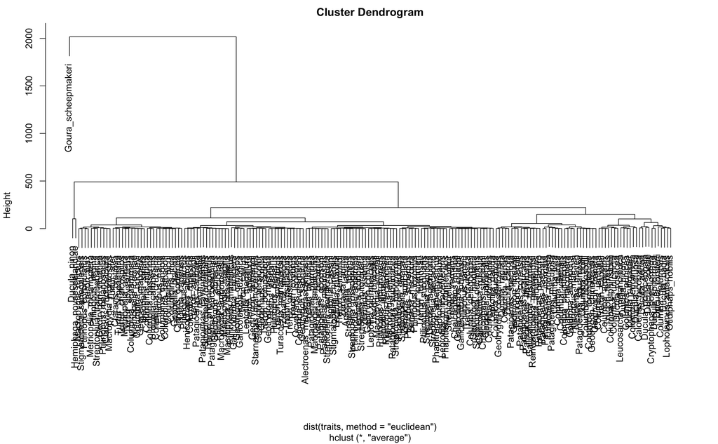

```r
analysis_all_traits = c('mass', 'locomotory_trait', 'trophic_trait')

get_traits_data_frame = function(trait_names) {
  trait_names = prepend('jetz_scientific_name', trait_names)
  traits = avonet_jetz[,trait_names]
  traits = tibble::column_to_rownames(traits, var='jetz_scientific_name')
  traits
}

get_dentrogram_for_traits = function(required_traits_for_dentro) {
  traits = get_traits_data_frame(required_traits_for_dentro)
  hclust(dist(traits,method="euclidean"), method="average")
}

dentro = get_dentrogram_for_traits(analysis_all_traits)
plot(dentro)
```

Petchey and Gaston’s FD

```r
get_fd_for_traits = function(required_traits_for_pd, communities, dentorgram = get_dentrogram_for_traits(required_traits_for_pd)) {
  result = pd(communities, as.phylo(dentorgram))
  data.frame(site = rownames(result), fd = result$PD)
}

urban_community_fd_result = get_fd_for_traits(analysis_all_traits, species_in_cities)
head(urban_community_fd_result)
```

|  | site | fd |
| --- | --- | --- |
| 1 | 514 | 1064.131 |
| 2 | 6660 | 1155.183 |
| 3 | 2054 | 1220.745 |
| 4 | 4358 | 1118.756 |
| 5 | 3079 | 1193.801 |
| 6 | 8 | 1118.756 |

```r
urban_community_fd_mass_result = get_fd_for_traits(c('locomotory_trait'), species_in_cities)
head(urban_community_fd_mass_result)
```

|  | site | fd |
| --- | --- | --- |
| 1 | 514 | 2.134889 |
| 2 | 6660 | 2.080574 |
| 3 | 2054 | 2.364559 |
| 4 | 4358 | 2.029615 |
| 5 | 3079 | 2.360600 |
| 6 | 8 | 2.029615 |

## Trait Variance

### FRic - Convex Hull of all traits

Using fundiversity package https://cran.r-project.org/web/packages/fundiversity/index.html Grenié M, Gruson H (2022). fundiversity: Easy Computation of Functional Diversity Indices. doi:10.5281/zenodo.4761754, R package version 1.1.1

```r
get_convex_hull = function(trait_names, communities) {
  analysis_trait_values = get_traits_data_frame(trait_names)
  fd_fric(analysis_trait_values, communities)
}

get_convex_hull(analysis_all_traits)
```

| site | FRic |
| --- | --- |
| s1 | 1816.891 |

### Single Trait Variance

How to get names of species in urban community:

```r
species_in_514 = species_in_cities[c('514'),]
species_names_in_514 = names(species_in_514)[which(species_in_514 == 1, arr.ind=T)[, "col"]]
species_names_in_514
```

```
[1] "Columbina_talpacoti" "Zenaida_auriculata"
```

How to get values of traits for species in urban community, and then var of those traits:

```r
trait_values = function(trait, community_row) {
  species_names_in_community = names(community_row)[which(community_row == 1, arr.ind=T)[, "col"]]
  traits_for_species_in_community = avonet_jetz[avonet_jetz$jetz_scientific_name %in% species_names_in_community, ]
  traits_for_species_in_community[[c(trait)]]
}

trait_values('mass', species_in_cities[c('514'),])
```

```
[1]  46.0 110.2
```

```r
var(trait_values('mass', species_in_cities[c('514'),]))
```

```
[1] 2060.82
```

Turn into a function:

```r
single_trait_variance = function(trait, communities) {
  variance_of_trait = data.frame()
  for(row in rownames(communities)) {
    community_row = communities[c(row),]
    species_names_in_community = names(community_row)[which(community_row == 1, arr.ind=T)[, "col"]]

    result = data.frame(site = row, variance = var(trait_values(trait, community_row)))
    variance_of_trait = rbind(variance_of_trait, result)
  }

  variance_of_trait
}

single_trait_variance('mass', species_in_cities)
```

| site | variance |
| --- | --- |
| 514 | 2060.8200 |
| 6660 | 10618.6133 |
| 2054 | 20053.0933 |
| 4358 | 21053.5200 |
| 3079 | 29471.6133 |
| 8 | 30603.3800 |
| 3593 | 21053.5200 |
| 2570 | 29471.6133 |
| 1291 | 9656.8492 |
| 2059 | 29471.6133 |

[output cut: 297 more lines]

## SDNDr

Standard deviation of distances between neighbouring species along a single trait axis, divided by the trait range of the community.

How to calculate SDNDr using trait values for an urban community:

```r
print('trait values:')
```

```
[1] "trait values:"
```

```r
sorted_loco_traits_in_1291 = sort(trait_values('locomotory_trait', species_in_cities[c('1291'),]))
sorted_loco_traits_in_1291
```

```
[1] -0.7067057 -0.3755905  0.1066861  0.2938382
```

```r
print('diff in neighbouring trait values:')
```

```
[1] "diff in neighbouring trait values:"
```

```r
diff(sorted_loco_traits_in_1291)
```

```
[1] 0.3311152 0.4822766 0.1871521
```

```r
print('SDNDr:')
```

```
[1] "SDNDr:"
```

```r
sd(diff(sorted_loco_traits_in_1291)) / (max(sorted_loco_traits_in_1291) - min(sorted_loco_traits_in_1291))
```

```
[1] 0.1474966
```

Turn into a function:

```r
SDNDr = function(trait, communities) {
  sdndr_of_trait = data.frame()
  for(row in rownames(communities)) {
    community_row = communities[c(row),]

    sorted_trait_values = sort(trait_values(trait, community_row))

    sdndr_value = sd(diff(sorted_trait_values)) / (max(sorted_trait_values) - min(sorted_trait_values))

    sdndr_of_trait = rbind(sdndr_of_trait, data.frame(site = row, sdndr = sdndr_value))
  }

  sdndr_of_trait
}

SDNDr('locomotory_trait', species_in_cities)
```

| site | sdndr |
| --- | --- |
| 514 | NA |
| 6660 | 0.14938876 |
| 2054 | 0.29292350 |
| 4358 | NA |
| 3079 | 0.11991869 |
| 8 | NA |
| 3593 | NA |
| 2570 | 0.11991869 |
| 1291 | 0.14749664 |
| 2059 | 0.11991869 |

[output cut: 297 more lines]

## Put it all together

```r
get_community_metrics = function(communities, included_traits = analysis_all_traits) {

  mntd_result = get_mntd_for_communities(communities)
  mtd_result = get_mtd_for_communities(communities)
  fd_all_traits = get_fd_for_traits(included_traits, communities)
  convex_hull = get_convex_hull(included_traits, communities)

  result = right_join(right_join(mntd_result, mtd_result), right_join(fd_all_traits, convex_hull))

  for (trait in included_traits) {
    col_name = function(value) {
      paste(trait, value, sep = '_')
    }

    fd_single_trait = get_fd_for_traits(trait, communities)
    var_single_trait = single_trait_variance(trait, communities)
    sdndr_single_trait = SDNDr(trait, communities)

    single_trait_result = right_join(right_join(fd_single_trait, var_single_trait), sdndr_single_trait)
    names(single_trait_result) = c('site', col_name('fd'), col_name('var'), col_name('sdndr'))
    result = right_join(result, single_trait_result)
  }

  result
}
```

```r
urban_community_values = get_community_metrics(species_in_cities)
```

```
Differing number of species between trait dataset and site-species matrix
Taking subset of species
Warning: Some sites had less species than traits so returned FRic is 'NA'Joining with `by = join_by(site)`Joining with `by = join_by(site)`Joining with `by = join_by(site)`Joining with `by = join_by(site)`Joining with `by = join_by(site)`Joining with `by = join_by(site)`Joining with `by = join_by(si…
```

```r
urban_community_values
```

| site | mntd | mtd | fd | FRic | mass_fd | mass_var | mass_sdndr | locomotory_trait_fd | locomotory_trait_var | locomotory_trait_sdndr | trophic_trait_fd | trophic_trait_var | trophic_trait_sdndr |
| --- | --- | --- | --- | --- | --- | --- | --- | --- | --- | --- | --- | --- | --- |
| 514 | 65.453574 | 65.453574 | 1064.131 | NA | 1064.126 | 2060.8200 | NA | 2.134889 | 5.481865e-02 | NA | 1.0052086 | 0.059689119 | NA |
| 6660 | 41.458651 | 50.815779 | 1155.183 | NA | 1155.177 | 10618.6133 | 0.11440519 | 2.080574 | 1.656736e-02 | 0.14938876 | 0.9397117 | 0.006424870 | 0.192847304 |
| 2054 | 19.685693 | 25.064082 | 1220.745 | 0.445718480 | 1220.737 | 20053.0933 | 0.12796322 | 2.364559 | 6.417422e-02 | 0.29292350 | 1.0480751 | 0.035509499 | 0.392994204 |
| 4358 | 32.101522 | 32.101522 | 1118.756 | NA | 1118.751 | 21053.5200 | NA | 2.029615 | 3.264896e-02 | NA | 0.8986683 | 0.005077720 | NA |
| 3079 | 24.371308 | 28.236415 | 1193.801 | NA | 1193.795 | 29471.6133 | 0.14390971 | 2.360600 | 9.560017e-02 | 0.11991869 | 1.0480751 | 0.051053541 | 0.377123617 |
| 8 | 52.594989 | 52.594989 | 1118.756 | NA | 1118.751 | 30603.3800 | NA | 2.029615 | 1.180376e-01 | NA | 0.8986683 | 0.085654145 | NA |
| 3593 | 32.101522 | 32.101522 | 1118.756 | NA | 1118.751 | 21053.5200 | NA | 2.029615 | 3.264896e-02 | NA | 0.8986683 | 0.005077720 | NA |
| 2570 | 24.371308 | 28.236415 | 1193.801 | NA | 1193.795 | 29471.6133 | 0.14390971 | 2.360600 | 9.560017e-02 | 0.11991869 | 1.0480751 | 0.051053541 | 0.377123617 |
| 1291 | 51.720917 | 57.661375 | 1186.402 | 1.774001727 | 1186.393 | 9656.8492 | 0.21075117 | 2.651489 | 2.073402e-01 | 0.14749664 | 1.2666056 | 0.107046632 | 0.253695997 |
| 2059 | 24.371308 | 28.236415 | 1193.801 | NA | 1193.795 | 29471.6133 | 0.14390971 | 2.360600 | 9.560017e-02 | 0.11991869 | 1.0480751 | 0.051053541 | 0.377123617 |

[output cut: 297 more lines]

```r
urban_resident_only_community_values = get_community_metrics(resident_species_in_cities)
```

```
Differing number of species between trait dataset and site-species matrix
Taking subset of species
Warning: Some sites had less species than traits so returned FRic is 'NA'Joining with `by = join_by(site)`Joining with `by = join_by(site)`Joining with `by = join_by(site)`Joining with `by = join_by(site)`Joining with `by = join_by(site)`Joining with `by = join_by(site)`Joining with `by = join_by(si…
```

```r
urban_resident_only_community_values
```

| site | mntd | mtd | fd | FRic | mass_fd | mass_var | mass_sdndr | locomotory_trait_fd | locomotory_trait_var | locomotory_trait_sdndr | trophic_trait_fd | trophic_trait_var | trophic_trait_sdndr |
| --- | --- | --- | --- | --- | --- | --- | --- | --- | --- | --- | --- | --- | --- |
| 514 | 65.453574 | 65.453574 | 1064.131 | NA | 1064.126 | 2060.8200 | NA | 2.134889 | 5.481865e-02 | NA | 1.0052086 | 0.059689119 | NA |
| 6660 | 41.458651 | 50.815779 | 1155.183 | NA | 1155.177 | 10618.6133 | 0.11440519 | 2.080574 | 1.656736e-02 | 0.14938876 | 0.9397117 | 0.006424870 | 0.192847304 |
| 4358 | 32.101522 | 32.101522 | 1118.756 | NA | 1118.751 | 21053.5200 | NA | 2.029615 | 3.264896e-02 | NA | 0.8986683 | 0.005077720 | NA |
| 8 | 52.594989 | 52.594989 | 1118.756 | NA | 1118.751 | 30603.3800 | NA | 2.029615 | 1.180376e-01 | NA | 0.8986683 | 0.085654145 | NA |
| 1291 | 51.720917 | 57.661375 | 1186.402 | 1.774001727 | 1186.393 | 9656.8492 | 0.21075117 | 2.651489 | 2.073402e-01 | 0.14749664 | 1.2666056 | 0.107046632 | 0.253695997 |
| 2059 | 24.371308 | 28.236415 | 1193.801 | NA | 1193.795 | 29471.6133 | 0.14390971 | 2.360600 | 9.560017e-02 | 0.11991869 | 1.0480751 | 0.051053541 | 0.377123617 |
| 3343 | 24.371308 | 28.236415 | 1193.801 | NA | 1193.795 | 29471.6133 | 0.14390971 | 2.360600 | 9.560017e-02 | 0.11991869 | 1.0480751 | 0.051053541 | 0.377123617 |
| 1040 | 32.903351 | 52.172584 | 1213.347 | 8.211037997 | 1213.335 | 15291.3620 | 0.13492851 | 2.674163 | 2.630933e-01 | 0.20238095 | 1.1355896 | 0.085282383 | 0.169949138 |
| 1296 | 56.881184 | 61.167379 | 1174.777 | NA | 1174.771 | 14484.0133 | 0.31743935 | 2.465874 | 2.598100e-01 | 0.23909366 | 1.2329455 | 0.160569948 | 0.095554970 |
| 530 | 41.703711 | 53.578642 | 1100.558 | NA | 1100.552 | 6454.3033 | 0.17288783 | 2.320504 | 8.927461e-02 | 0.02555808 | 1.0302190 | 0.082918826 | 0.017677670 |

[output cut: 235 more lines]

# Calculate the null models

Our null model is every possible community of species from the regional pool with the same richness as the urban pool

Find all species in regional pool:

```r
test_city_id = 1786 # Manchester

all_columbidae_communities$jetz_scientific_name[all_columbidae_communities$city_id == test_city_id]
```

```
[1] "Columba_livia"         "Streptopelia_decaocto" "Columba_oenas"         "Columba_palumbus"      "Streptopelia_turtur"
```

```r
all_columbidae_communities$jetz_scientific_name[all_columbidae_communities$city_id == test_city_id]
```

```
[1] "Columba_livia"         "Streptopelia_decaocto" "Columba_oenas"         "Columba_palumbus"      "Streptopelia_turtur"
```

Find urban richness

```r
selected_urban_communities$urban_pool_size[selected_urban_communities$city_id == test_city_id]
```

```
[1] 4
```

Function to build every possible community

```r
create_null_model_communities = function(city_id, urban_richness, regional_species) {
  regional_richness = length(regional_species)

  null_model_sites = expand.grid(rep(list(TRUE:FALSE), regional_richness))
  null_model_sites_species_richness =  data.frame(species_richness = pmap_dbl(null_model_sites, sum))
  null_model_sites = cbind(null_model_sites, null_model_sites_species_richness)

  null_model_sites = null_model_sites[null_model_sites$species_richness == urban_richness,1:regional_richness]
  colnames(null_model_sites) = regional_species
  null_model_sites
}

create_null_model_communities(
  test_city_id,
  selected_urban_communities$urban_pool_size[selected_urban_communities$city_id == test_city_id],
  all_columbidae_communities$jetz_scientific_name[all_columbidae_communities$city_id == test_city_id]
)
```

|  | Columba_livia | Streptopelia_decaocto | Columba_oenas | Columba_palumbus | Streptopelia_turtur |
| --- | --- | --- | --- | --- | --- |
| 2 | 0 | 1 | 1 | 1 | 1 |
| 3 | 1 | 0 | 1 | 1 | 1 |
| 5 | 1 | 1 | 0 | 1 | 1 |
| 9 | 1 | 1 | 1 | 0 | 1 |
| 17 | 1 | 1 | 1 | 1 | 0 |

What were the results for the actual urban community in Manchester?

```r
urban_community_values[urban_community_values$site == test_city_id,]
```

|  | site | mntd | mtd | fd | FRic | mass_fd | mass_var | mass_sdndr | locomotory_trait_fd | locomotory_trait_var | locomotory_trait_sdndr | trophic_trait_fd | trophic_trait_var | trophic_trait_sdndr |
| --- | --- | --- | --- | --- | --- | --- | --- | --- | --- | --- | --- | --- | --- | --- |
| 301 | 1786 | 19.68569 | 25.06408 | 1220.745 | 0.4457185 | 1220.737 | 20053.09 | 0.1279632 | 2.364559 | 0.06417422 | 0.2929235 | 1.048075 | 0.0355095 | 0.3929942 |

Test creating community metrics for our null model

```r
test_null_models = create_null_model_communities(
  test_city_id,
  selected_urban_communities$urban_pool_size[selected_urban_communities$city_id == test_city_id],
  all_columbidae_communities$jetz_scientific_name[all_columbidae_communities$city_id == test_city_id]
)

test_null_model_community_values = get_community_metrics(test_null_models)
```

```
Differing number of species between trait dataset and site-species matrix
Taking subset of species
```

```r
test_null_model_community_values
```

| site | mntd | mtd | fd | FRic | mass_fd | mass_var | mass_sdndr | locomotory_trait_fd | locomotory_trait_var | locomotory_trait_sdndr | trophic_trait_fd | trophic_trait_var | trophic_trait_sdndr |
| --- | --- | --- | --- | --- | --- | --- | --- | --- | --- | --- | --- | --- | --- |
| 2 | 18.92930 | 27.71078 | 1200.512 | 0.1000553 | 1200.501 | 27478.28 | 0.2602083 | 2.409256 | 0.09192034 | 0.2445250 | 1.0658455 | 0.038549223 | 0.3756476 |
| 3 | 19.68569 | 25.06408 | 1220.745 | 0.7598791 | 1220.737 | 22074.68 | 0.1390673 | 2.364559 | 0.07344991 | 0.2835130 | 0.8381086 | 0.031416235 | 0.4551187 |
| 5 | 18.92930 | 27.71078 | 1200.512 | 0.5679672 | 1200.501 | 29554.63 | 0.2658504 | 2.409256 | 0.09214486 | 0.2407513 | 1.0658455 | 0.038549223 | 0.3756476 |
| 9 | 15.20996 | 26.47100 | 1152.411 | 0.1537513 | 1152.398 | 11759.43 | 0.2838886 | 2.082230 | 0.02564227 | 0.4277439 | 0.9164388 | 0.002400691 | 0.2973809 |
| 17 | 19.68569 | 25.06408 | 1220.745 | 0.4457185 | 1220.737 | 20053.09 | 0.1279632 | 2.364559 | 0.06417422 | 0.2929235 | 1.0480751 | 0.035509499 | 0.3929942 |

```r
test_city_id2 = 8
get_community_metrics(
  create_null_model_communities(
    test_city_id2,
    selected_urban_communities$urban_pool_size[selected_urban_communities$city_id == test_city_id2],
    all_columbidae_communities$jetz_scientific_name[all_columbidae_communities$city_id == test_city_id2]
  )
)
```

```
Differing number of species between trait dataset and site-species matrix
Taking subset of species
Warning: Some sites had less species than traits so returned FRic is 'NA'Joining with `by = join_by(site)`Joining with `by = join_by(site)`Joining with `by = join_by(site)`Joining with `by = join_by(site)`Joining with `by = join_by(site)`Joining with `by = join_by(site)`Joining with `by = join_by(si…
```

| site | mntd | mtd | fd | FRic | mass_fd | mass_var | mass_sdndr | locomotory_trait_fd | locomotory_trait_var | locomotory_trait_sdndr | trophic_trait_fd | trophic_trait_var | trophic_trait_sdndr |
| --- | --- | --- | --- | --- | --- | --- | --- | --- | --- | --- | --- | --- | --- |
| 2 | 52.59499 | 52.59499 | 1118.756 | NA | 1118.751 | 30603.380 | NA | 2.029615 | 0.11803756 | NA | 0.8986683 | 0.08565415 | NA |
| 3 | 65.45357 | 65.45357 | 1064.131 | NA | 1064.126 | 3486.125 | NA | 2.134889 | 0.05015544 | NA | 1.0052086 | 0.08417098 | NA |
| 5 | 65.45357 | 65.45357 | 1118.756 | NA | 1118.751 | 54747.405 | NA | 2.134889 | 0.32207902 | NA | 1.0052086 | 0.33964378 | NA |

# Compare Urban Communities to regional null models

```r
normalise = function(actual_value, min_value, max_value) {
  (actual_value - min_value) / (max_value - min_value)
}

normalise(1.5, 1, 2)
```

```
[1] 0.5
```

```r
standardise = function(actual_value, mean_value, sd) {
  (actual_value - mean_value) / sd
}

standardise(1.5, 1, 0.25)
```

```
[1] 2
```

Test creating normalised and standardised FRic

```r
property = 'FRic'
actual_value = urban_community_values[urban_community_values$site == test_city_id,c(property)]
null_model_values = test_null_model_community_values[,c(property)]

print(paste('Normalised', property, 'at site', test_city_id))
```

```
[1] "Normalised FRic at site 1786"
```

```r
normalise(actual_value, min(null_model_values), max(null_model_values))
```

```
[1] 0.523872
```

```r
print(paste('Standardised', property, 'at site', test_city_id))
```

```
[1] "Standardised FRic at site 1786"
```

```r
standardise(actual_value, mean(null_model_values), sd(null_model_values))
```

```
[1] 0.1444982
```

Create function to test actual value against all possible null model values

```r
compare_community_to_null_model = function(metric_name, actual_metric_value, null_model_metric_values) {
  min_value = min(null_model_metric_values)
  max_value = max(null_model_metric_values)
  mean_value = mean(null_model_metric_values)
  sd_value = sd(null_model_metric_values)

  result = data.frame(
    normalised = normalise(actual_metric_value, min_value, max_value),
    stanardised = standardise(actual_metric_value, mean_value, sd_value),
    actual = actual_metric_value,
    min = min_value,
    max = max_value,
    mean = mean_value,
    sd = sd_value
  )

  col_name = function(value) {
      paste(metric_name, value, sep = '_')
  }

  colnames(result) = c(col_name('normalised'), col_name('standardised'), col_name('actual'), col_name('min'), col_name('max'), col_name('mean'), col_name('sd'))
  result
}

compare_community_to_null_model(property, actual_value, null_model_values)
```

| FRic_normalised | FRic_standardised | FRic_actual | FRic_min | FRic_max | FRic_mean | FRic_sd |
| --- | --- | --- | --- | --- | --- | --- |
| 0.523872 | 0.1444982 | 0.4457185 | 0.1000553 | 0.7598791 | 0.4054743 | 0.2785101 |

The metrics we want to test:

```r
all_metrics_to_test = colnames(urban_community_values)[-1]
all_metrics_to_test
```

```
 [1] "mntd"                   "mtd"                    "fd"                     "FRic"                   "mass_fd"                "mass_var"
 [7] "mass_sdndr"             "locomotory_trait_fd"    "locomotory_trait_var"   "locomotory_trait_sdndr" "trophic_trait_fd"       "trophic_trait_var"
[13] "trophic_trait_sdndr"
```

Compare the actual values to the null model values:

```r
create_null_model_test_values = function(city_id, urban_richness, regional_species, actual_values) {
  null_models = create_null_model_communities(city_id, urban_richness, regional_species)
  null_model_community_values = get_community_metrics(null_models)

  result = data.frame(city_id = city_id)

  for (metric in all_metrics_to_test) {
    result = cbind(result,
                   compare_community_to_null_model(metric, actual_values[,c(metric)], null_model_community_values[,c(metric)]))
  }
  result
}

create_null_model_test_values(
  test_city_id,
  selected_urban_communities$urban_pool_size[selected_urban_communities$city_id == test_city_id],
  all_columbidae_communities$jetz_scientific_name[all_columbidae_communities$city_id == test_city_id],
  urban_community_values[urban_community_values$site == test_city_id,]
)
```

```
Differing number of species between trait dataset and site-species matrix
Taking subset of species
```

| city_id | mntd_normalised | mntd_standardised | mntd_actual | mntd_min | mntd_max | mntd_mean | mntd_sd | mtd_normalised | mtd_standardised | mtd_actual | mtd_min | mtd_max | mtd_mean | mtd_sd | fd_normalised | fd_standardised | fd_actual | fd_min | fd_max | fd_mean | fd_sd | FRic_normalised | FRic_standardised | FRic_actual | FRic_min | FRic_max | FRic_mean | FRic_sd | mass_fd_normalised | … |
| --- | --- | --- | --- | --- | --- | --- | --- | --- | --- | --- | --- | --- | --- | --- | --- | --- | --- | --- | --- | --- | --- | --- | --- | --- | --- | --- | --- | --- | --- | --- |
| 1786 | 1 | 0.6401094 | 19.68569 | 15.20996 | 19.68569 | 18.48799 | 1.871094 | 2.266975e-10 | -1.012226 | 25.06408 | 25.06408 | 27.71078 | 26.40415 | 1.323877 | 1 | 0.7790413 | 1220.745 | 1152.411 | 1220.745 | 1198.985 | 27.93233 | 0.523872 | 0.1444982 | 0.4457185 | 0.1000553 | 0.7598791 | 0.4054743 | 0.2785101 | 1 | … |

```r
create_null_model_test_values(
  test_city_id2,
  selected_urban_communities$urban_pool_size[selected_urban_communities$city_id == test_city_id2],
  all_columbidae_communities$jetz_scientific_name[all_columbidae_communities$city_id == test_city_id2],
  urban_community_values[urban_community_values$site == test_city_id2,]
)
```

```
Differing number of species between trait dataset and site-species matrix
Taking subset of species
Warning: Some sites had less species than traits so returned FRic is 'NA'Joining with `by = join_by(site)`Joining with `by = join_by(site)`Joining with `by = join_by(site)`Joining with `by = join_by(site)`Joining with `by = join_by(site)`Joining with `by = join_by(site)`Joining with `by = join_by(si…
```

| city_id | mntd_normalised | mntd_standardised | mntd_actual | mntd_min | mntd_max | mntd_mean | mntd_sd | mtd_normalised | mtd_standardised | mtd_actual | mtd_min | mtd_max | mtd_mean | mtd_sd | fd_normalised | fd_standardised | fd_actual | fd_min | fd_max | fd_mean | fd_sd | FRic_normalised | FRic_standardised | FRic_actual | FRic_min | FRic_max | FRic_mean | FRic_sd | mass_fd_normalised | … |
| --- | --- | --- | --- | --- | --- | --- | --- | --- | --- | --- | --- | --- | --- | --- | --- | --- | --- | --- | --- | --- | --- | --- | --- | --- | --- | --- | --- | --- | --- | --- |
| 8 | 0 | -1.154701 | 52.59499 | 52.59499 | 65.45357 | 61.16738 | 7.423907 | 0 | -1.154701 | 52.59499 | 52.59499 | 65.45357 | 61.16738 | 7.423907 | 1 | 0.5773503 | 1118.756 | 1064.131 | 1118.756 | 1100.548 | 31.53752 | NA | NA | NA | NA | NA | NA | NA | 1 | … |

And for resident only species

```r
create_null_model_test_values(
  test_city_id2,
  selected_resident_only_urban_communities$urban_pool_size[selected_resident_only_urban_communities$city_id == test_city_id2],
  all_resident_columbidae_communities$jetz_scientific_name[all_resident_columbidae_communities$city_id == test_city_id2],
  urban_resident_only_community_values[urban_resident_only_community_values$site == test_city_id2,]
)
```

```
Differing number of species between trait dataset and site-species matrix
Taking subset of species
Warning: Some sites had less species than traits so returned FRic is 'NA'Joining with `by = join_by(site)`Joining with `by = join_by(site)`Joining with `by = join_by(site)`Joining with `by = join_by(site)`Joining with `by = join_by(site)`Joining with `by = join_by(site)`Joining with `by = join_by(si…
```

| city_id | mntd_normalised | mntd_standardised | mntd_actual | mntd_min | mntd_max | mntd_mean | mntd_sd | mtd_normalised | mtd_standardised | mtd_actual | mtd_min | mtd_max | mtd_mean | mtd_sd | fd_normalised | fd_standardised | fd_actual | fd_min | fd_max | fd_mean | fd_sd | FRic_normalised | FRic_standardised | FRic_actual | FRic_min | FRic_max | FRic_mean | FRic_sd | mass_fd_normalised | … |
| --- | --- | --- | --- | --- | --- | --- | --- | --- | --- | --- | --- | --- | --- | --- | --- | --- | --- | --- | --- | --- | --- | --- | --- | --- | --- | --- | --- | --- | --- | --- |
| 8 | 0 | -1.154701 | 52.59499 | 52.59499 | 65.45357 | 61.16738 | 7.423907 | 0 | -1.154701 | 52.59499 | 52.59499 | 65.45357 | 61.16738 | 7.423907 | 1 | 0.5773503 | 1118.756 | 1064.131 | 1118.756 | 1100.548 | 31.53752 | NA | NA | NA | NA | NA | NA | NA | 1 | … |

```r
ALL_SPECIES_RESULT__CACHE_FILE = './cache/community_assembly_all_species_result.csv'

if(!file.exists(ALL_SPECIES_RESULT__CACHE_FILE)) {
  urban_all_species_community_result = data.frame()

  for (loop_all_city_id in selected_urban_communities$city_id) {
    city_null_models_all_species = create_null_model_test_values(
      loop_all_city_id,
      selected_urban_communities$urban_pool_size[selected_urban_communities$city_id == loop_all_city_id],
      all_columbidae_communities$jetz_scientific_name[all_columbidae_communities$city_id == loop_all_city_id],
      urban_community_values[urban_community_values$site == loop_all_city_id,]
    )

    urban_all_species_community_result = rbind(urban_all_species_community_result, city_null_models_all_species)
  }

  urban_all_species_community_result = right_join(urban_all_species_community_result, selected_urban_communities)

  write_csv(urban_all_species_community_result, ALL_SPECIES_RESULT__CACHE_FILE)
} else {
  urban_all_species_community_result = read_csv(ALL_SPECIES_RESULT__CACHE_FILE)
}
```

[output not shown]

[output cut: 499 more lines]

[output not shown]

```r
head(urban_all_species_community_result)
```

|  | city_id | mntd_normalised | mntd_standardised | mntd_actual | mntd_min | mntd_max | mntd_mean | mntd_sd | mtd_normalised | mtd_standardised | mtd_actual | mtd_min | mtd_max | mtd_mean | mtd_sd | fd_normalised | fd_standardised | fd_actual | fd_min | fd_max | fd_mean | fd_sd | FRic_normalised | FRic_standardised | FRic_actual | FRic_min | FRic_max | FRic_mean | FRic_sd | … |
| --- | --- | --- | --- | --- | --- | --- | --- | --- | --- | --- | --- | --- | --- | --- | --- | --- | --- | --- | --- | --- | --- | --- | --- | --- | --- | --- | --- | --- | --- | --- |
| 1 | 8 | 0.0000000 | -1.1547005 | 52.59499 | 52.59499 | 65.45357 | 61.16738 | 7.423907 | 0.000000e+00 | -1.15470054 | 52.59499 | 52.59499 | 65.45357 | 61.16738 | 7.423907 | 1.00000000 | 0.5773503 | 1118.756 | 1064.131 | 1118.756 | 1100.548 | 31.53752 | NA | NA | NA | NA | NA | NA | NA | … |
| 2 | 56 | 0.0000000 | -1.8211876 | 29.82878 | 29.82878 | 65.45357 | 55.22991 | 13.947566 | 0.000000e+00 | -1.82118760 | 29.82878 | 29.82878 | 65.45357 | 55.22991 | 13.947566 | 0.00000000 | -1.5134514 | 1024.478 | 1024.478 | 1118.756 | 1084.835 | 39.88013 | NA | NA | NA | NA | NA | NA | NA | … |
| 3 | 65 | 0.4187096 | -0.2010766 | 41.70371 | 30.77122 | 56.88118 | 44.06633 | 11.749859 | 5.304327e-01 | -0.08172503 | 53.57864 | 45.00625 | 61.16738 | 54.11702 | 6.587721 | 0.09930391 | -0.9657986 | 1080.500 | 1070.105 | 1174.777 | 1126.017 | 47.12963 | NA | NA | NA | NA | NA | NA | NA | … |
| 4 | 74 | 1.0000000 | 0.6187576 | 65.45357 | 13.43004 | 65.45357 | 54.11702 | 18.321471 | 1.000000e+00 | 0.61875760 | 65.45357 | 13.43004 | 65.45357 | 54.11702 | 18.321471 | 0.47813637 | -0.3225136 | 1064.131 | 1014.084 | 1118.756 | 1077.011 | 39.93556 | NA | NA | NA | NA | NA | NA | NA | … |
| 5 | 75 | 0.1446419 | -1.3379996 | 23.29700 | 18.49049 | 51.72092 | 37.58395 | 10.677846 | 1.297617e-11 | -2.84620667 | 38.39550 | 38.39550 | 57.66138 | 52.66946 | 5.015083 | 0.18956828 | -1.1676826 | 1070.932 | 1042.813 | 1191.146 | 1129.802 | 50.41565 | 0 | -0.7684961 | 0.003176166 | 0.003176166 | 8.405721 | 1.635685 | 2.124291 | … |
| 6 | 79 | 0.4187096 | -0.2010766 | 41.70371 | 30.77122 | 56.88118 | 44.06633 | 11.749859 | 5.304327e-01 | -0.08172503 | 53.57864 | 45.00625 | 61.16738 | 54.11702 | 6.587721 | 0.09930391 | -0.9657986 | 1080.500 | 1070.105 | 1174.777 | 1126.017 | 47.12963 | NA | NA | NA | NA | NA | NA | NA | … |

```r
RESIDENT_SPECIES_RESULT__CACHE_FILE = './cache/community_assembly_resident_species_result.csv'
urban_resident_only_species_community_result = NULL

if (!file.exists(RESIDENT_SPECIES_RESULT__CACHE_FILE)) {
  urban_resident_only_species_community_result = data.frame()

  for (loop_resident_city_id in selected_resident_only_urban_communities$city_id) {
    city_null_models_resident_species = create_null_model_test_values(
      loop_resident_city_id,
      selected_resident_only_urban_communities$urban_pool_size[selected_resident_only_urban_communities$city_id == loop_resident_city_id],
      all_resident_columbidae_communities$jetz_scientific_name[all_resident_columbidae_communities$city_id == loop_resident_city_id],
      urban_resident_only_community_values[urban_resident_only_community_values$site == loop_resident_city_id,]
    )

    urban_resident_only_species_community_result = rbind(urban_resident_only_species_community_result, city_null_models_resident_species)
  }

  urban_resident_only_species_community_result = right_join(urban_resident_only_species_community_result, selected_urban_communities)

  write_csv(urban_resident_only_species_community_result, RESIDENT_SPECIES_RESULT__CACHE_FILE)
} else {
  urban_resident_only_species_community_result = read_csv(RESIDENT_SPECIES_RESULT__CACHE_FILE)
}

head(urban_resident_only_species_community_result)
```

[output not shown]

# Analysis

Total number of cities in analysis

```r
nrow(urban_all_species_community_result)
```

```
[1] 307
```

Total number of cities in resident only species analysis

```r
nrow(urban_resident_only_species_community_result)
```

[output not shown]

## Analysis of all traits across entire community

### MNTD

Pairwise phylogenetic distances separating each species from its closest co-occurring relative and is most sensitive to phylogenetic clustering or evenness at the tips of phylogeny.

#### All species

Standardised

Normalised

#### Resident only species

Normalised

### MTD

Mean pairwise phylogenetic distances between co-occurring species and is most sensitive to tree-wide patterns of phylogenetic clustering and evenness.

#### All species

Standardised

Normalised

#### Resident only species

Normalised

### All Traits FD

#### All species

Standardised

Normalised:

#### Resident only species

Normalised

### FRic

#### All species

Standardised

Normalised

#### Resident only species

Normalised

## Single Trait Metrics

### Locomotory Trait

#### FD

##### All species

Standardised

Normalised

##### Resident only species

Normalised

#### VAR

##### All species

Standardised

Normalised

##### Resident only species

Normalised

#### SDNDr

##### All species

Standardised

Normalised

##### Resident only species

Normalised

### Trophic Trait

#### FD

##### All species

Standardised

Normalised

##### Resident only species

Normalised

#### VAR

##### All species

Standardised

Normalised

##### Resident only species

Normalised

#### SDNDr

##### All species

Standardised

Normalised

##### Resident only species

Normalised

### Mass

#### FD

##### All species

Standardised

Normalised

##### Resident only species

Normalised

#### VAR

##### All species

Standardised

Normalised

##### Resident only species

Normalised

#### SDNDr

##### All species

Standardised

Normalised

##### Resident only species

Normalised

## Create Figures

### All Traits

Standardised

Normalised

Normalised - resident only species

### Single Traits

Standardised

Normalised

Locomotory metrics compared

Trophic metrics compared

Mass metrics compared

Normalised - resident only species

# Impact of Introduced species

## Is there any difference in MNTD or FD of cities with introduced species?